# re_stepwise

Flueckiger_Rubens; 21-118-385

2025-04-06

# Report re_stepwise

## 1 Loading packages and dataset

```r
#Packages
library(dplyr)
library(ggplot2)

#Dataset
half_hourly_fluxes <- read.table("../data/half_hourly_ecosystem_fluxes.csv", sep = ";", header = T)
```

Information about the dataset

The dataset contains following variables:

- **TA_F**: Air temperature
- **SW_IN_F**: Shortwave radiation, incoming
- **LW_IN_F**: Longwave radiation, incoming
- **VPD_F**: Vapor Pressure Deficit
- **PA_F**: Atmospheric pressure consolidated from PA and PA_ERA
- **WS_F**: Wind speed, consolidated from WS and WS_ERA
- **TA_F_MDS**: Air temperature, gap filled using MDS method
- **SW_IN_F_MDS**: Shortwave radiation, incoming, gap filled using MDS (negative values set to zero, e.g., negative values from instrumentation noise)
- **VPD_F_MDS**: Vapor Pressure Deficit, gap filled using MDS
- **CO2_F_MDS**: CO2 mole fraction, gap filled with MDS
- **PPFD_IN**: Photosynthetic photon flux density, incoming
- **GPP_NT_VUT_REF**: Gross Primary Production, from Nighttime partitioning method, reference selected from GPP versions using model efficiency (MEF). The MEF analysis is repeated for each time aggregation
- **USTAR**: Friction velocity

## 2 Data set preproces

Including:

- deleting all NA values
- deleting all non-numeric values

```r
data <- half_hourly_fluxes %>%
  select(-starts_with("TIMESTAMP")) %>% #Delete row with date
  select(-starts_with("siteid")) %>% #Delete row with site information
  tidyr::drop_na() #Drop all values with NA
```

## 3 Performing forward selection

### 3.1 Step 1

linear regression with just 1 dependent variable

In this step the code loops over all parameters to check for the best fitted linear model. Note that in a first step within the loop we need to check if the model tries to fit the modelling parameter with itself. Obviously this is not wanted and since modelling a parameter with itself is a perfect fit, it will break the code. Therefore we only calculate the model when the column of the dataset not matches the column of the modelling variable.

Then a model with the i-th variable gets created. After extracting the R<sup>2</sup> value the program checks if the extracted value (*r_2*) is bigger than the previous R<sup>2</sup> value (*validation*; default = 0 meaning no correlation between variable and GPP). If the statement is true, *validation* is overwritten with r_2 and the current column i is stored inside the column index storeing vector *col*.

After the loop the AIC of the highest performing variable gets created.

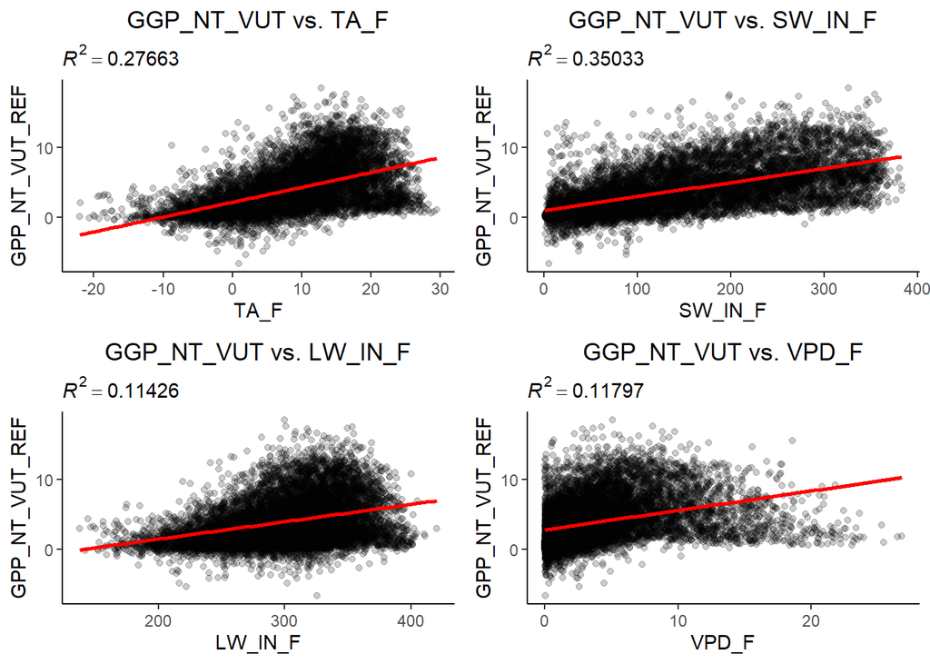

Figure 1: Results by applying Step 1

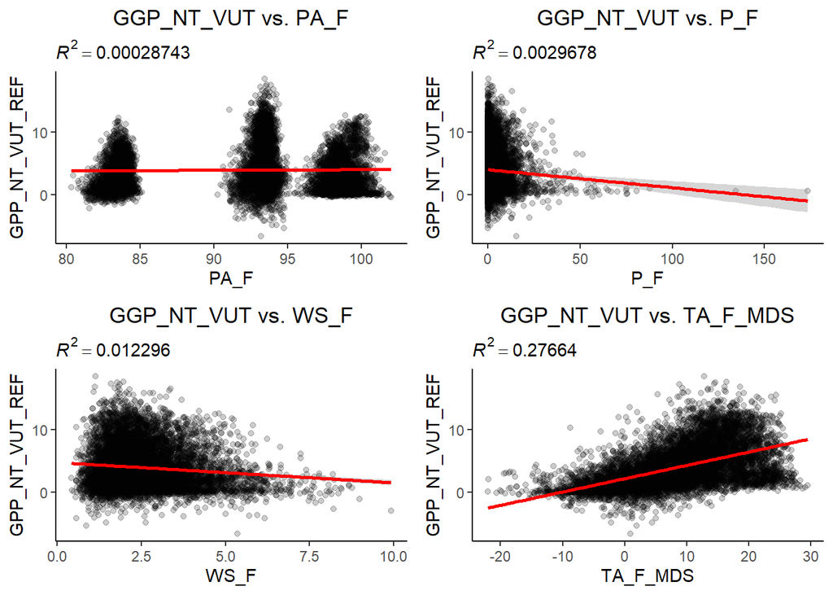

Figure 2: Results by applying Step 1

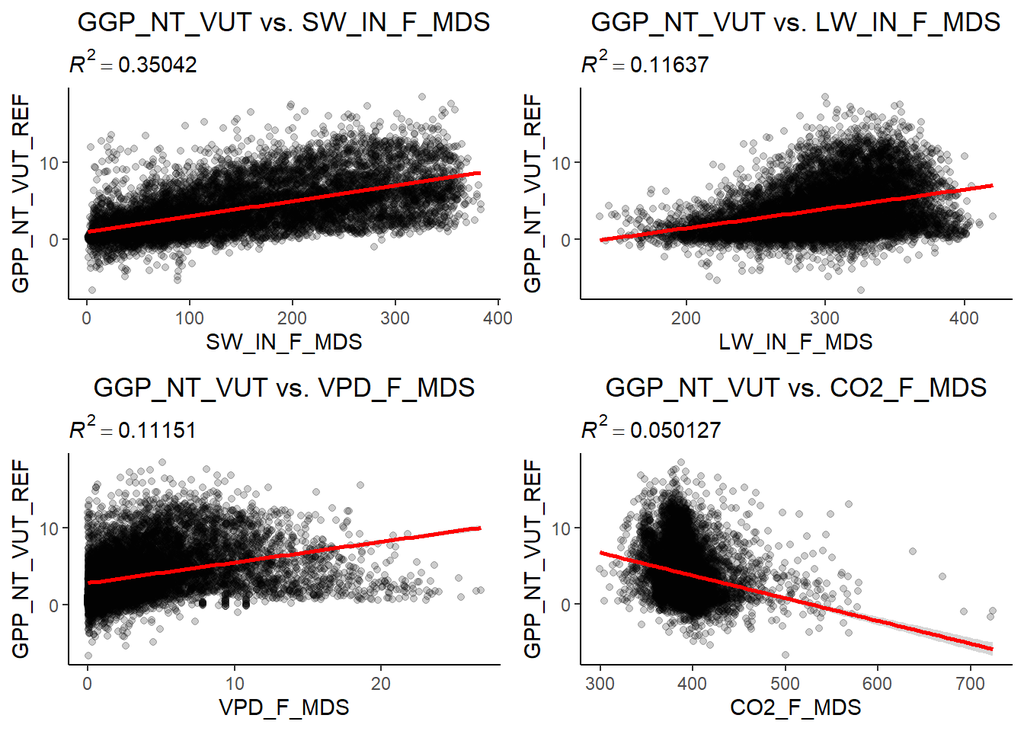

Figure 3: Results by applying Step 1

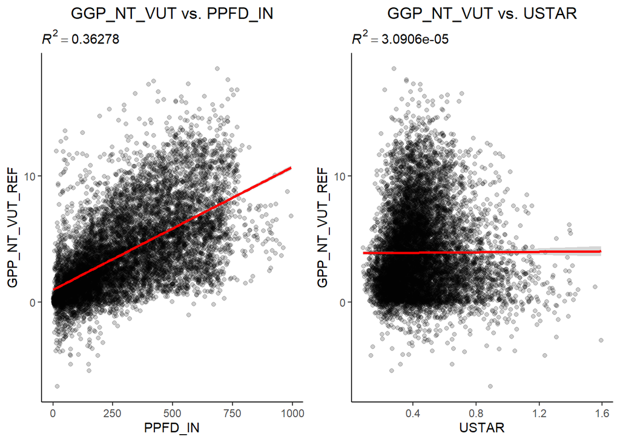

Figure 4: Results by applying Step 1

As a first approximation, the GPP (the rate at which solar energy is captured in sugar molecules during photosynthetic process) is only dependent on the photon flux density (*PPFD_IN*) inside the leaf. This should be obvious for a non-radiation energy limited system since for such a system the production rate is limited by the production rate of the plant itself which in return is limited by the formation rate of sugar which is dependent on the photon flux. Therefore, as a first approximation, wind speed, air temperature, vapor density and atmospheric pressure can be neglected.

### 3.2 Step 2

adding another variable to previous calculated variable

To continue the forward selection process another loop gets created. This loop will terminate as soon as a terminating value *term* no longer matches a predefined value (here: 1). This is done such that the program can terminate as soon as a threshold is achieved (here: Adding a variable does not add a significant benefit to the model anymore. Or: AIC is higher than the previous AIC).

Inside this loop, the step above gets repeated. Additionally the program has to check whether the j-th column already has been used to model the GPP. If the statement is false, the program can continue. Since plotting the result has more than two dimensions and cannot be performed, it is neglected in the process below *Note:* In contrast to step 1, the best performing variable gets stored in an other variable first. This is done such that the goodness of the additional variable can be checked (by calculating the AIC). If the AIC is lower than the previous one, the column can be appended to the *col* vector and the program continues to add a new variable to the model. If not, the column does not add the column to *col* and the program gets terminated.

## 4 Final results

Following parameters in descending order of importance (first has the highest explanation of the GPP variable) are relevant for modeling the GPP:

```
## [1] "PPFD_IN"
```

To visualize and verify the result, a regression model and a principal component analysis (PCA) is performed.

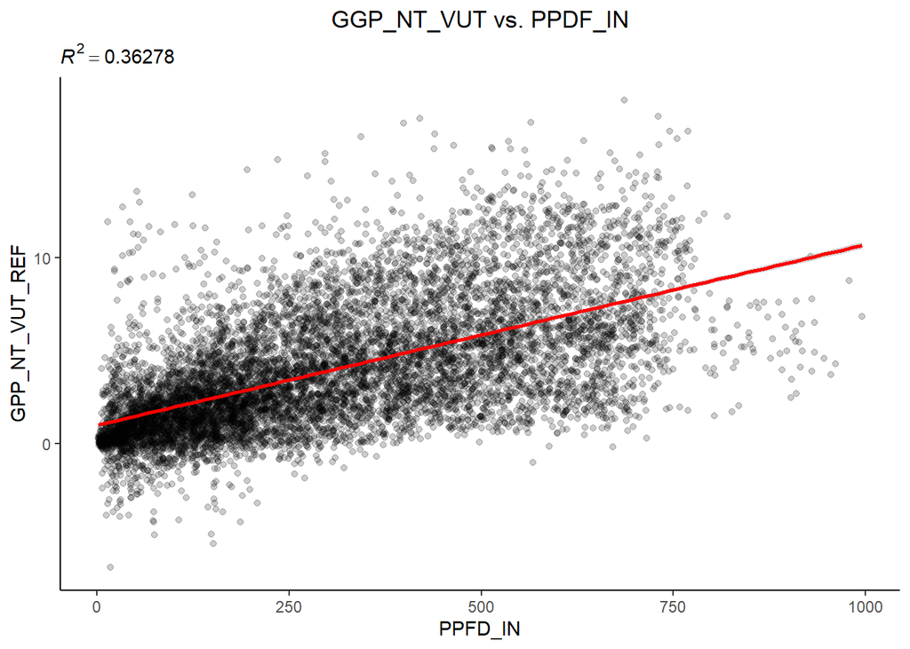

Figure 5: GPP as a function of the most relevant parameter

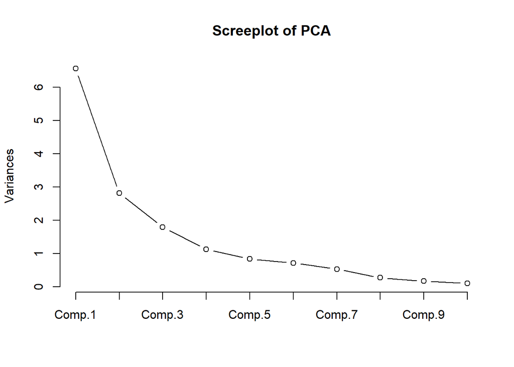

Figure 6: Principal component analysis

```r
#Principal component analysis (PCA)
fit <- princomp(data, cor = T)
plot(fit, type = "l", main = "Screeplot of PCA") #Screeplot
```

By identifying the kink at the screeplot, one can see how many relevant components there are inside the dataset. In this case one can see that there are two principal components. Since the modeling parameter GPP is one component, it only needs one other component to (mainly) model the parameter.

The neglection of the incoming long- and shortwave radiation might occur due to limitation of photon flux inside the leaf rather than due to radiation from the sun. This means that over the whole observed interval there was always enough radiation abundant to benefit sugar production inside the plant and the sugar production rate was only limited by the production rate of the plant itself. The same argument can be used for the CO<sub>2</sub> mole fraction (*CO2_F_MDS*).